# Multivariate Analysis

### Talk about some of the relationships you observed in this part of the investigation. Were there features that strengthened each other in terms of looking at your feature(s) of interest?

Looking at the relationship between player age and injuries, it was interesting that for certain position groups (RB, WR, TE), there was a significant jump in injury rates as players reached their low- to mid-30’s.

### Were there any interesting or surprising interactions between features?

The relationship between draft position and 40-yard dash times broken down by player position was fascinating to me. It was clear that for certain positions, there was a positive correlation between 40-yard dash time and draft position, at least within certain ranges.

# Final Plots and Summary

### Plot One

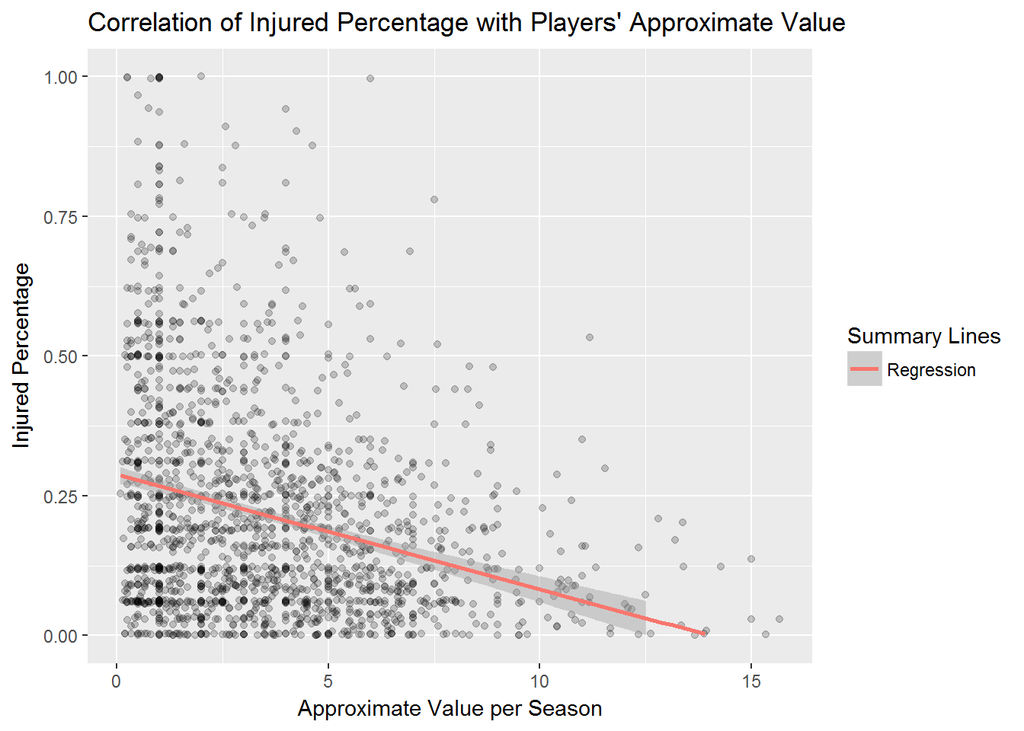

### Description One

This plot compares a player’s approximate value, as calculated by Pro Football Reference, with the percentage of games missed due to injury throughout their careers. This is somewhat to be expected, as the less time you’re on the field, the less chance you have of providing value to your team. But to me it’s a cool look at this relationship, and helps to quantify the effect that injury rates have on a player’s value. NFL teams have to consider this all the time when acquiring players. There are some teams that make a habit of drafting injured players, for example, thinking that by selecting the player when he’s injured, they can get him at a discounted price, so to speak. At some point, though, they have to consider whether the expected value of the player will be worth the time missed due to injury, and a plot like this is a first step in looking at that relationship.

### Plot Two

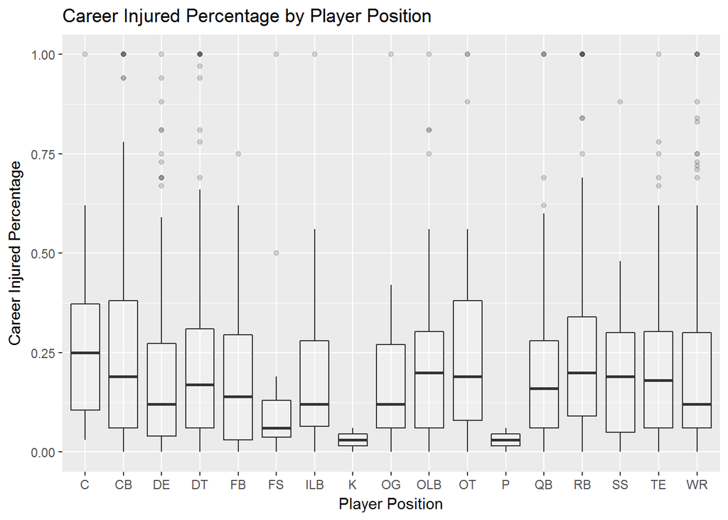

### Plot Three

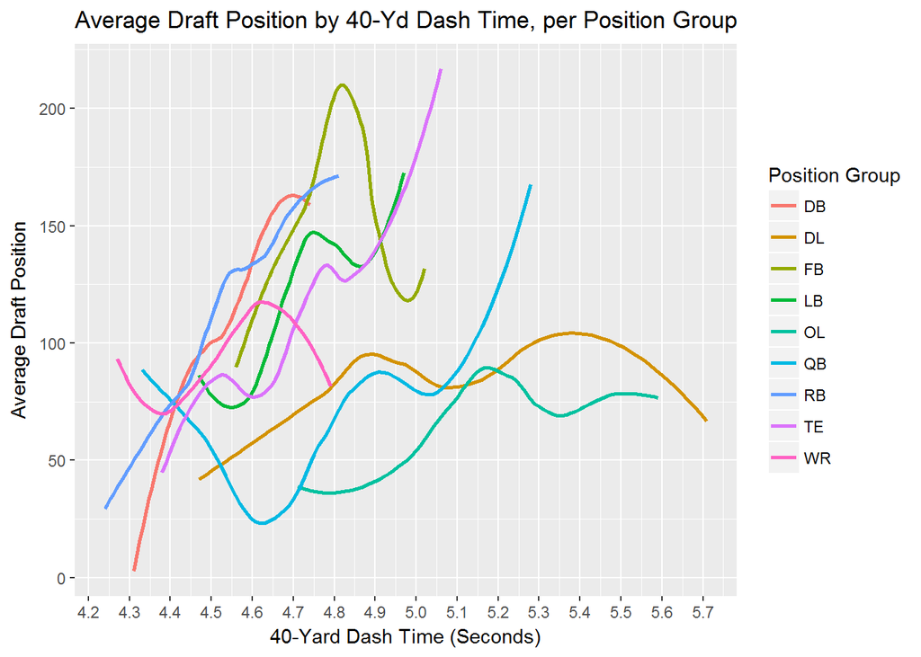

### Description Three

I thought this was a cool look at how a major athleticism test–the 40-yard dash–affects where players are drafted in the NFL. There are clear positive correlations, at least within certain ranges, between the run times and the players’ draft position. The correlation is also stronger for certain positions, such as defensive back, than for others, such as defensive line.

# Reflection

I went into this analysis really excited to look at injury rates compared to combine statistics, and was a little disappointed that there were no clear correlations to be found in that area. In retrospect, this shouldn’t have been all that surprising, as there’s so much randomness to injuries, and it’s really hard to find strong correlation, especially when I don’t have information about the types of injuries each player had. I do think with more data (injury types, player weight over career, etc.), it would be possible to find stronger correlations. Also, this was a bit outside the scope of this project, but I think it would be cool to look at advanced statistics (rushing yards after contact, receiving yards per route run, etc.) and how they correlated with player value and draft position. Another cool angle would be to look at advanced athletic performance measurements (i.e. SPARQ), and see how that influenced draft position and injury rates.

# References

N/A